# A modeling example

### selectEV(…)

Part 2 of variable selection using `MIAmaxent` is performed by the `selectEV` function. This function is similar to the `selectDVforEV` function, but instead of selecting parsimonious groups of derived variables to represent each explanatory variable, `selectEV` selects explanatory variables. This proceeds in the same manner as `selectDVforEV`, with nested model comparison using the F-test. Where `selectDVforEV` adds a single DV at a time, `selectEV` adds a single *group of DVs*, representing a single EV, at a time.

The `selectEV` function also differs from `selectDVforEV` in one other very important way; it includes the option of including interaction terms between selected explanatory variables in the model (`interaction = TRUE`). Interaction terms between variables are useful when one explanatory variable changes the effect of another explanatory variable on the modeled target. In `MIAmaxent` interaction terms are produced by simple multiplication between all pairs of derived variables representing the two interacting explanatory variables. Interaction terms are only allowed between EVs which are both included in the model.

Here we use `selectEV` on the grassland data set. Note the “[[1]]” following grasslandsDVselect, which specifies the list of selected DVs in the `selectDVforEV` output (see `?selectDVforEV` Value).

```r
grasslandEVselect <- selectEV(grasslandPO, grasslandDVselect[[1]], alpha = 0.001, interaction = TRUE)
```

```
#> Forward selection of 10 EVs
#> Round 1 complete.
#> Round 2 complete.
#> Round 3 complete.
#> Round 4 complete.
#> Round 5 complete.
#> Round 6 complete.
#> Round 7 complete.
#> Round 8 complete.
#> Forward selection of interaction terms between 8 EVs
#> Round 9 complete.
#> Round 10 complete.
#> Round 11 complete.
```

The output of selectEV consists of 2 main parts:

- the EVs that were selected (named “selectedEV”), each represented by a group of selected DVs.
- the trail of nested models that were built and compared during the selection process (named “selection”)

Now compare the list of EVs before and after:

```r
summary(grasslandDVselect[[1]])
```

```
#>            Length Class      Mode
#> pca1       1      data.frame list
#> pr-bygall  1      data.frame list
#> pr-tilany  1      data.frame list
#> teraspif   1      data.frame list
#> terdem     2      data.frame list
#> tertpi09   2      data.frame list
#> geoberg    6      data.frame list
#> geolmja1   5      data.frame list
#> lcucor1    7      data.frame list
#> terslpps15 1      data.frame list
```

```r
length(grasslandDVselect[[1]])
```

```
#> [1] 10
```

```r
summary(grasslandEVselect[[1]])
```

```
#>                    Length Class      Mode
#> pr-bygall          1      data.frame list
#> terslpps15         1      data.frame list
#> lcucor1            7      data.frame list
#> geoberg            6      data.frame list
#> geolmja1           5      data.frame list
#> teraspif           1      data.frame list
#> pca1               1      data.frame list
#> tertpi09           2      data.frame list
#> terslpps15:lcucor1 7      data.frame list
#> pr-bygall:geoberg  6      data.frame list
#> terslpps15:geoberg 6      data.frame list
```

```r
length(grasslandEVselect[[1]])
```

```
#> [1] 11
```

We can see that `selectEV` has reduced the number of explanatory variables to 8, but it has also added 3 new interaction terms between explanatory variables selected for the model.

Here we show the best model of each round in the trail of forward selection of EVs and interaction terms, hiding a few columns for readability:

```
#>    round model  m trainAUC        FVA    addedFVA dfe       Pvalue
#> 1      1     2  1   0.6240 0.03665027 0.036650266   1 0.000000e+00
#> 11     2     1  2   0.6425 0.04538880 0.008738530   1 0.000000e+00
#> 20     3     3  9   0.6684 0.06657527 0.021186478   7 0.000000e+00
#> 28     4     1 15   0.6829 0.08094927 0.014373991   6 0.000000e+00
#> 35     5     1 20   0.6858 0.08458735 0.003638082   5 1.096012e-12
#> 39     6     1 21   0.6883 0.08701274 0.002425388   1 4.239120e-11
#> 42     7     1 22   0.6908 0.08911712 0.002104381   1 7.701719e-10
#> 44     8     1 24   0.6933 0.09164951 0.002532390   2 1.227807e-10
#> 45     9     8 31   0.6967 0.09500225 0.003352742   7 1.142393e-10
#> 73    10     2 37   0.6990 0.09660729 0.001605036   6 5.871502e-05
#> 78    11     1 43   0.7005 0.09842633 0.001819041   6 1.044218e-05
```

The full selection trail is automatically saved as a CSV-format file in the directory specified by the `dir` argument in `selectEV`. It is recommended to open this file (named: “evselection.csv”) using spreadsheet software to inspect the trail of forward selection more closely. This allows the user to make an informed decision about what is the best model.

> **The trail of forward variable selection is automatically written to file (in the specified `dir`), and can be examined more closely using spreadsheet software.**

We can also look at the selection trail in graphical form. For example, we may plot additional variation explained across round number, to see how much better the model fit is for each round of adding a variable:

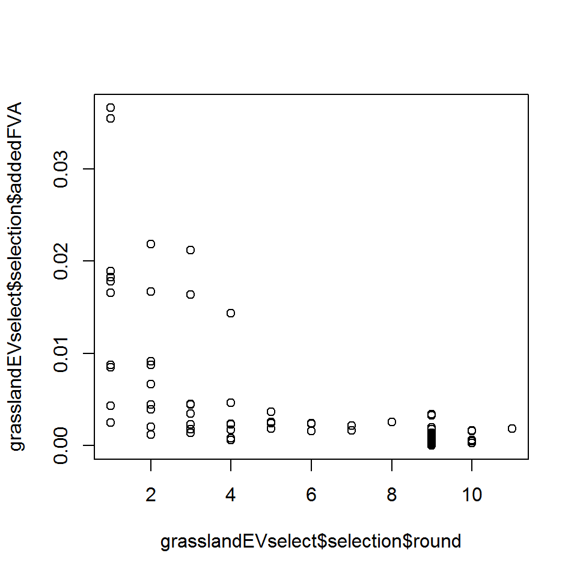

```r
plot(grasslandEVselect$selection$round, grasslandEVselect$selection$addedFVA)
```

For example, we may decide that a simple model with only 4 explanatory variables is best, since rounds 5-11 explain only small amounts of additional variation. Thus, we choose the best model in round 4:

```r
grasslandEVselect[[2]][grasslandEVselect$selection$round == 4, ][1, -13]
```

```
#>    round model                                   EV  m trainAUC Entropy
#> 28     4     1 pr-bygall terslpps15 lcucor1 geoberg 15   0.6829  9.5418
#>           FVA   addedFVA dfe   dfu Fstatistic Pvalue
#> 28 0.08094927 0.01437399   6 16403   42.75726      0
```

The explanatory variables included in this model are: pr-bygall, terslpps15, lcucor1, and geoberg.

## Exploring the model

After building a model by selecting which explanatory variable to include, it is useful to explore what the model actually looks like. A straightforward way to do this is to look at model predictions over a range of explanatory data. This gives the modeler a sense of the relationships that the model has captured between explanatory variables and response variables, and can also help the modeler understand strengths and weaknesses in the model.

### plotResp(…)

We can use the `plotResp` function to create a so-called response plot. A response plot graphs model output across the range of one particular explanatory variable. When other variables are excluded from the model entirely, this is called a “single-effect response plot”.

Here we examine a single-effect response plot for the most important explanatory variable included in the model chosen above:

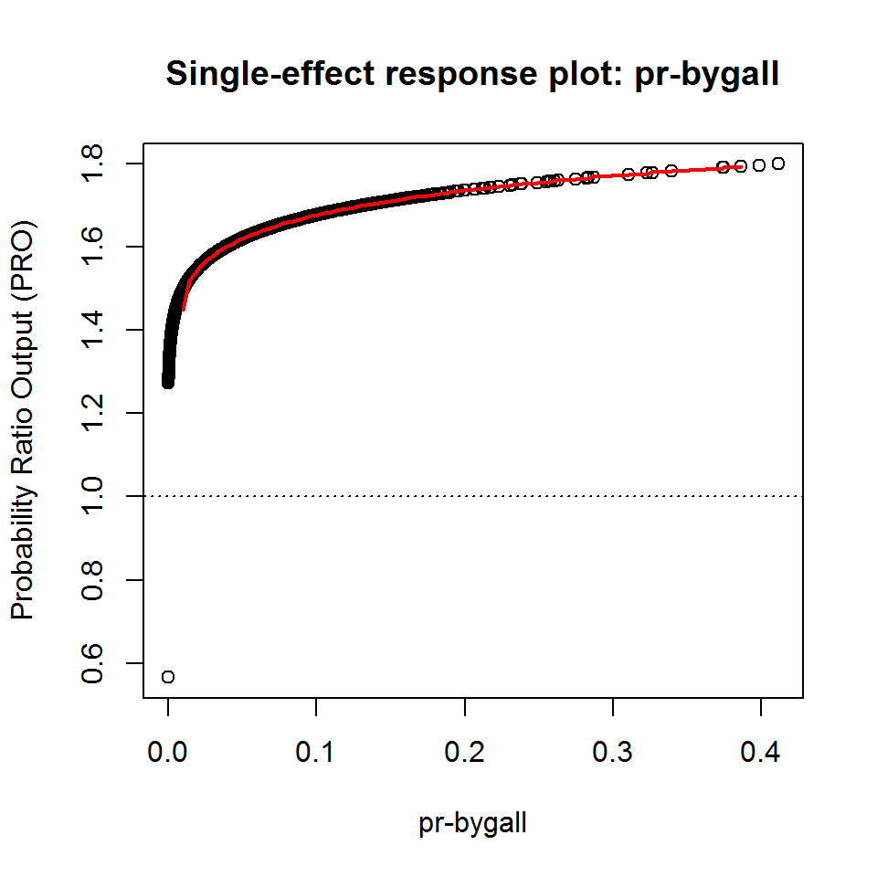

```r
prbygallResp <- plotResp(grasslandPO, grasslandEVselect[[1]], "pr-bygall")
```

To assess how well the relationship between the explanatory variable and the response variable is captured by the model, it can be useful to examine FOP plots and response plots side-by-side:

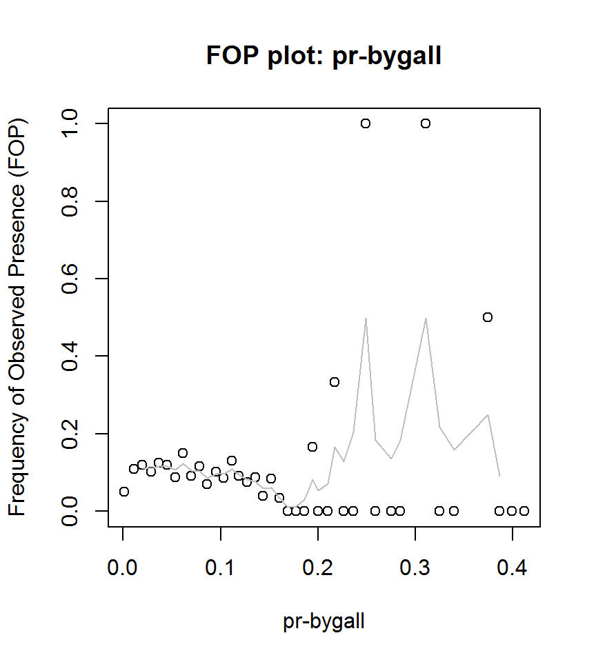

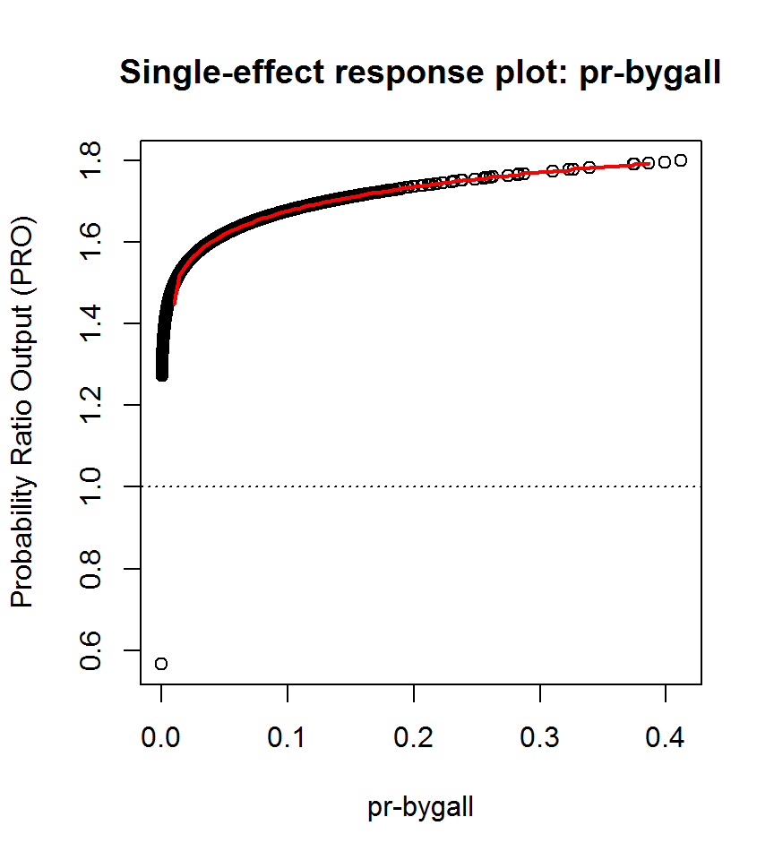

```r
prbygallFOP <- plotFOP(grasslandPO, "pr-bygall", intervals=50)
prbygallResp <- plotResp(grasslandPO, grasslandEVselect[[1]], "pr-bygall")
```

The values on the y-axes of the plots are not directly comparable, but one can expect that the shape of the response plot curve should mirror, to a greater or lesser extent, the shape of the FOP plot curve.

Here is the same comparison for one of the categorical variables included in the model:

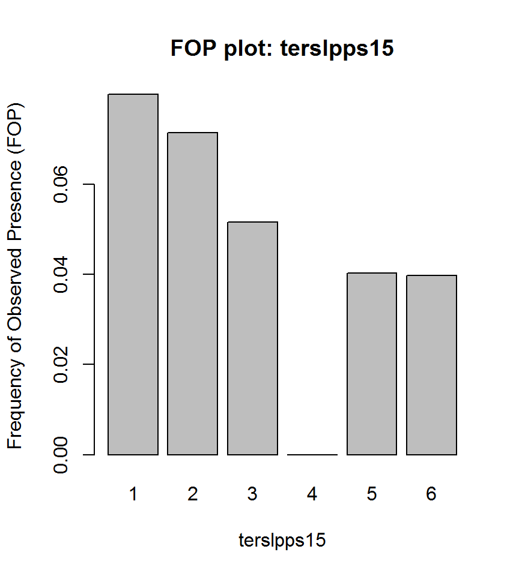

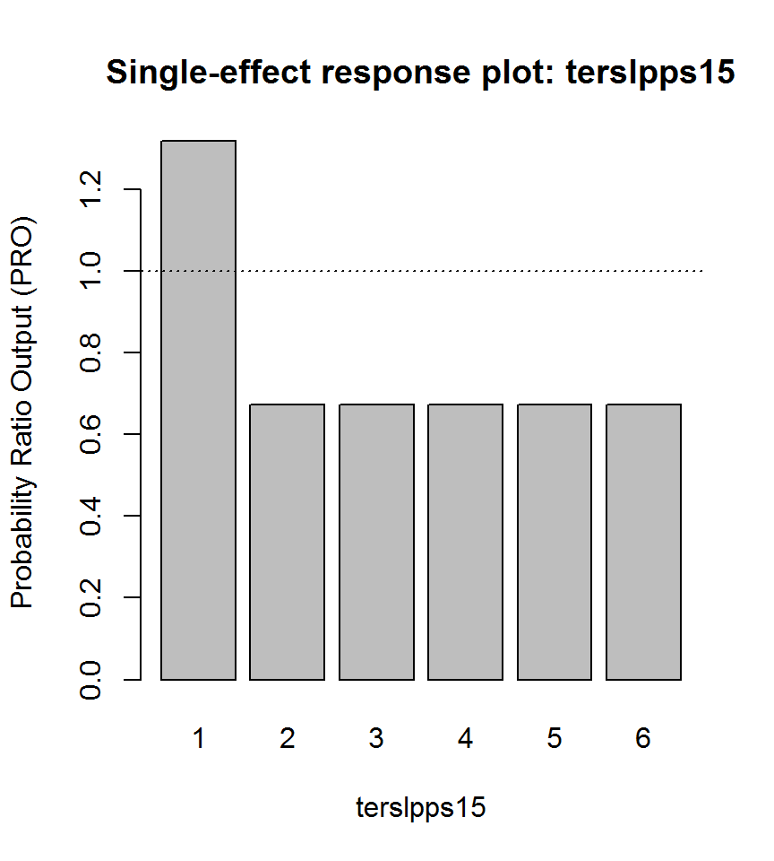

```r
terslpps15FOP <- plotFOP(grasslandPO, "terslpps15")
terslpps15Resp <- plotResp(grasslandPO, grasslandEVselect[[1]], "terslpps15")
```

### plotResp2(…)

The `plotResp2` function in `MIAmaxent` is very similar to the `plotResp` function in that it is used to produce model response plots. However, `plotResp2` produces “marginal-effect response plots” instead of “single-effect response plots”. A marginal-effect response plot graphs model output across the range of one particular explanatory variable *while holding all other variables in the model constant at their mean value*.

The two response plot functions also work in distinctly different ways, so the input to the functions differs.

Here is the marginal-effect response plot for the same continuous explanatory variable shown above (note that the `transformation` and `model` arguments will normally be file paths in the user-specified directory; see `?plotResp2` Examples):

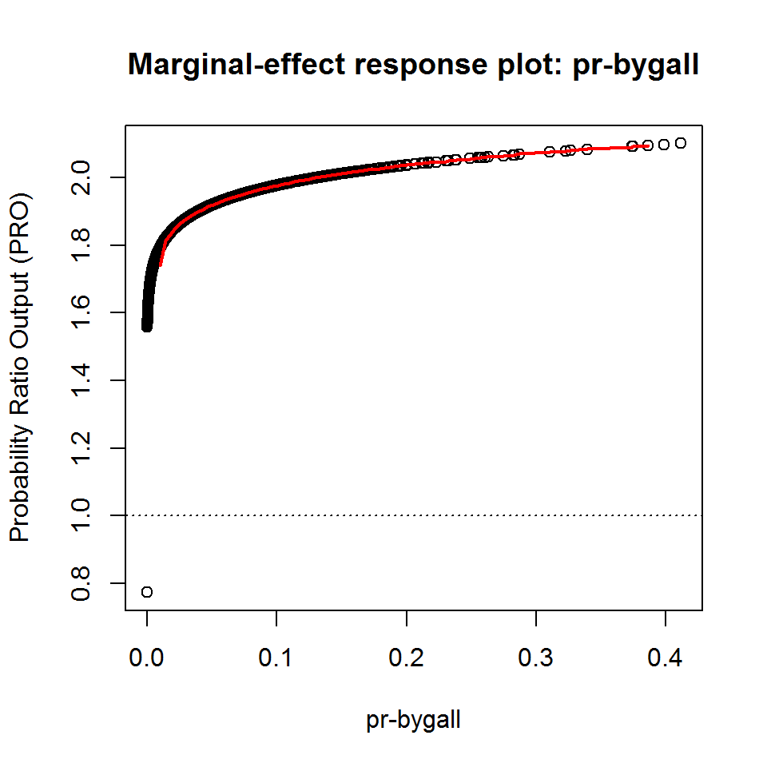

```r
prbygallResp2 <- plotResp2(grasslandPO, "pr-bygall",
  transformation = grasslandDVs[[2]],
  model = system.file("extdata", "1.lambdas", package = "MIAmaxent"))
```

## Using the model

For many modeling applications the ultimate motivation for building a model is to obtain model predictions. Model predictions, or model output, can be used in many different ways: to make predictions about parts of the study area for which there exist no occurrence data, to predict relative probability of occurrence outside the study area, or to predict relative probability of occurrence in the past or future. In other words, any form of spatial or temporal interpolation or extrapolation is possible (although not always recommended!). The only requirement is that the values of the explanatory variables are known for the time or space for which model output is desired.

### projectModel(…)

The `projectModel` function in `MIAmaxent` can be used to obtain model output for any kind of modeling application. As input it takes values for he explanatory variables in the model (`data`), the transformation functions used by the model (`transformations`), and the model parameters (`model`). It returns model predictions in probability ratio output (PRO) format for each location represented in `data`. PRO format represents *relative* probability of presence, and is a simple linear rescaling of raw Maxent output format such that PRO = 1 can be used as a reference value.

> **A value of PRO = 1 can be interpreted as the expected relative probability of a cell randomly drawn from the study area. Put another way, cells with PRO > 1 have a greater relative probability of presence than an “average” cell in the study area.**

Here, we obtain model output across the extent of the study area as represented by the training data (note again that the `transformation` and `model` arguments will normally be file paths in the user-specified directory; see `?projectModel` Examples):

```r
grasslandPrediction <- projectModel(grasslandPO,
    transformation = grasslandDVs[[2]],
    model = system.file("extdata", "1.lambdas", package = "MIAmaxent"))
```

Model predictions are appended to the `data` in column 1:

```r
head(grasslandPrediction$output)
```

```
#>        PRO RV     pca1   pr-bygall  pr-tilany teraspif terdem terslpdg
#> 1 7.992374  1 0.000504 0.007722008 0.00000000      180      0 0.000000
#> 2 7.413602  1 0.000506 0.001340483 0.00000000       95      0 0.826522
#> 3 2.002704  1 0.000554 0.002998501 0.38980511       20      0 1.433240
#> 4 3.252026  1 0.000510 0.010492330 0.08837772      111     12 1.174920
#> 5 7.294755  1 0.000486 0.000919963 0.13155469      116      0 0.812506
#> 6 5.088422  1 0.000545 0.002666667 0.00000000       61      0 0.794121
#>   tersolrade  tertpi09 geoberg geolmja1 lcucor1 lcutil-t4 terslpps15
#> 1    977.173  -3.54321      28       43     523         0          1
#> 2    966.094  -7.50617      28       42     523         0          1
#> 3   1017.510  -6.11111      27      130     523         1          1
#> 4    955.928  -2.38272      28       42     211         1          6
#> 5    959.591 -15.16050      28       43     523         0          1
#> 6    994.558  -9.91358      28       42     211         0          1
```

Additionally, the `projectModel` function automatically checks how the range of the input explanatory data compares to the range of the data used to train the model. This is important because if the range of the input data lies outside the range of the training data (called model extrapolation), the model is less reliable. The range of continuous variables is reported on the training data scale, from 0 to 1, and the range of categorical variables is reported as “inside” if all categories are represented in the training data:

```r
grasslandPrediction$ranges
```

```
#> $geoberg
#> [1] "inside"
#>
#> $lcucor1
#> [1] "inside"
#>
#> $pca1
#> [1] 0 1
#>
#> $`pr-bygall`
#> [1] 0 1
#>
#> $terslpps15
#> [1] "inside"
```

Since we projected the model over the training data, it makes sense that all the ranges are reported as [0,1] or “inside”.

Note that `MIAmaxent` never uses any location data in the modelling process – Maxent distribution modelling is not spatially explicit. Therefore, if model predictions are to be used in a spatial context (mapped), it can be helpful to include spatial coordinates in the `data` input to the `projectModel`. Here is some code (using the `raster` package again) that shows an example of how to plot model predictions spatially:

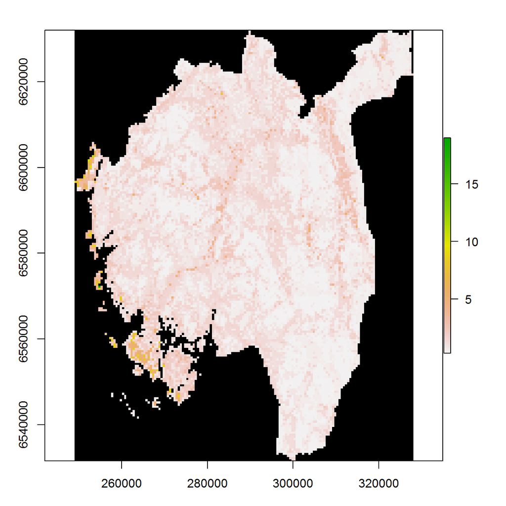

Model predictions in probability ratio output (PRO) across the study area

```r
grasslandPOXY <- readData(occurrence = system.file("extdata", "occurrence_PO.csv", package = "MIAmaxent"),
    contEV = system.file("extdata", "EV_continuous", package = "MIAmaxent"),
    catEV = system.file("extdata", "EV_categorical", package = "MIAmaxent"),
    maxbkg = 20000, XY = TRUE)
spatialPrediction <- projectModel(grasslandPOXY, transformation = grasslandDVs[[2]],
    model = system.file("extdata", "1.lambdas", package = "MIAmaxent"))

library(raster)
Predictionraster <- raster(list.files(system.file("extdata", "EV_continuous", package = "MIAmaxent"), full.names = TRUE)[1])
Predictionraster <- rasterize(spatialPrediction$output[, c("x", "y")], Predictionraster, field = spatialPrediction$output$PRO)
par(mar=c(3.1,3.1,2.1,0.1))
plot(Predictionraster, colNA="black")
par(mar=c(5.1,4.1,4.1,2.1))
```

## Evaluating the model

There are many ways of evaluating the quality of a model, including assessing the explanatory variables selected and gauging the realism of response curves. Arguably the best way to evaluate a model, however, is to test how often its predictions are correct using occurrence data which are independent from the data used to train the model. This gives a precise metric of model accuracy, and ensures that the model success is not the result of peculiarities of the training data (such as sampling bias). Independent, presence-absence test data are not always available, for example when projecting a model into the future, but when they are, they represent a gold standard in model evaluation.

### testAUC(…)

The evaluation metric which is used most commonly for distribution models and is implemented in `MIAmaxent` is Area Under the Curve (AUC) of the receiver operating characteristic. This is a metric which measures the performance of the model as a binary classifier over the full range of discrimination thresholds. When calculated using the training data `MIAmaxent` refers to it as “trainAUC” (for example in the forward selection trails), and when it is calculated using independent test data it is referred to as “testAUC”.

The `testAUC` function takes a data frame of presence or absence locations, along with the corresponding values of explanatory variable at those locations, and calculates a testAUC value for the model. The presence-absence occurrence data can be read into R using the `readData` function with `PA = TRUE` if desired.

In our example, 122 test locations in Øsfold County, Norway, were visited to record presence or absence of semi-natural grasslands. Plotted on the raster of model predictions these data look like this:

```r
grasslandPA <- readData(occurrence = system.file("extdata", "occurrence_PA.csv", package = "MIAmaxent"),
  contEV = system.file("extdata", "EV_continuous", package = "MIAmaxent"),
  catEV = system.file("extdata", "EV_categorical", package = "MIAmaxent"),
  PA = TRUE, XY = TRUE)
head(grasslandPA)
```

```
#>   RV      x       y     pca1   pr-bygall  pr-tilany teraspif terdem
#> 1  1 262750 6557250 0.000646 0.002871206 0.45159969       93     24
#> 2  1 263250 6558750 0.000635 0.029484030 0.01523342      109     19
#> 3  1 263750 6555250 0.000694 0.000970874 0.92038828       41      0
#> 4  1 265250 6555750 0.000719 0.003206413 0.27815631        7     13
#> 5  1 265250 6559750 0.000652 0.002914238 0.27019149      151     20
#> 6  1 266750 6553750 0.000848 0.012106540 0.21468930       49     10
#>   terslpdg tersolrade  tertpi09 geoberg geolmja1 lcucor1 lcutil-t4
#> 1 1.114550    967.471   8.67901      21      100     311         0
#> 2 1.236990    956.743   1.50617      21      100     322         0
#> 3 0.365185    981.625 -10.39510      21      130     523         1
#> 4 0.326633    988.487  -4.71605      21      130     322         1
#> 5 1.382270    941.362   6.06173      21      130     311         1
#> 6 0.769991    985.827   2.41975      21      130     322         1
#>   terslpps15
#> 1          6
#> 2          6
#> 3          1
#> 4          5
#> 5          6
#> 6          6
```

```r
tail(grasslandPA)
```

```
#>     RV      x       y     pca1 pr-bygall pr-tilany teraspif terdem
#> 117  0 313250 6575250 0.000788         0 1.0101010      131    132
#> 118  0 313750 6579250 0.000650         0 1.0076010       39    149
#> 119  0 314250 6572750 0.000545         0 0.3865006       78    139
#> 120  0 314250 6576750 0.000694         0 1.0060360       81    141
#> 121  0 314750 6571250 0.000640         0 0.0000000      102    174
#> 122  0 314750 6574750 0.000745         0 0.9434344      166    130
#>     terslpdg tersolrade tertpi09 geoberg geolmja1 lcucor1 lcutil-t4
#> 117 0.045296   1000.920 -3.39507      29      100     312         1
#> 118 1.358030   1022.570 -1.76543      62      130     312         1
#> 119 0.146076   1001.790 -7.23457      82       12     312         1
#> 120 1.689610   1028.010  3.16049      62       12     312         1
#> 121 1.501690    983.568 12.33330      82      130     312         0
#> 122 0.449772    988.030 -6.40741      62       12     312         1
#>     terslpps15
#> 117          1
#> 118          6
#> 119          1
#> 120          6
#> 121          6
#> 122          1
```

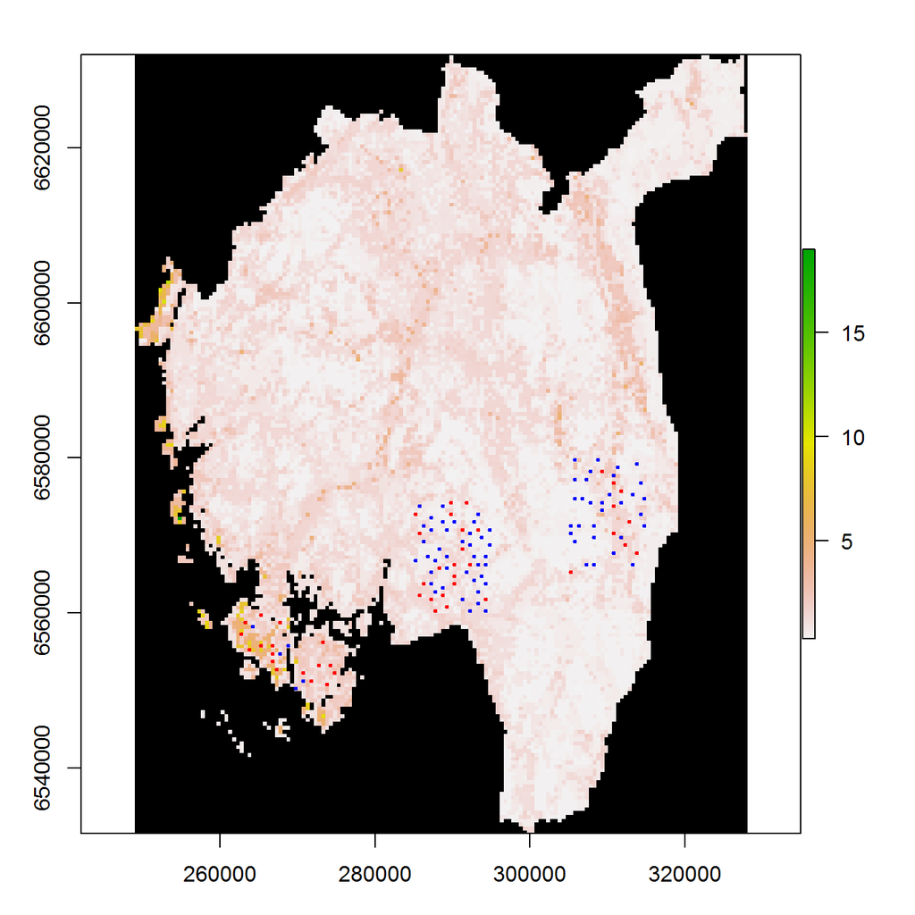

Presence (red) and absence (blue) test data plotted over model predictions

```r
par(mar=c(3.1,3.1,2.1,0.1))
plot(Predictionraster, colNA="black")
presences <- grasslandPA[grasslandPA$RV==1, ]
absences <- grasslandPA[grasslandPA$RV==0, ]
points(presences$x, presences$y, pch = 20, cex = 0.5, col = 'red')
points(absences$x, absences$y, pch = 20, cex = 0.5, col = 'blue')
par(mar=c(5.1,4.1,4.1,2.1))
```

We can use these data to calculate testAUC for our distribution model:

```r
grasslandAUC <- testAUC(grasslandPA,
  transformation = grasslandDVs[[2]],
  model = system.file("extdata", "1.lambdas", package = "MIAmaxent"))
grasslandAUC
```

```
#> [1] 0.819651
```

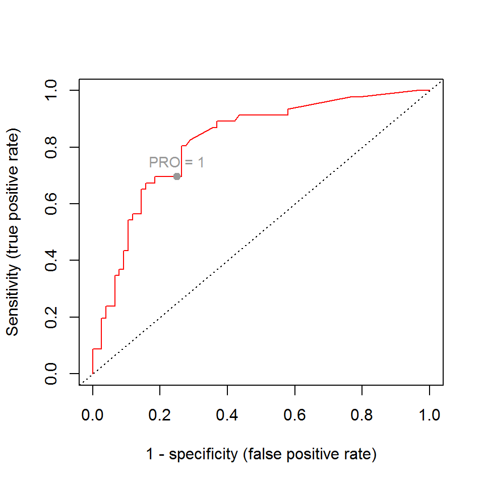

The ROC plot produced by `testAUC` shows how the rate of true positives as well as false positives increases as the binary classification threshold is lowered. The area under this curve corresponds to the value of testAUC.

## Acknowledgements

Thank you to Sabrina Mazzoni and Rune Halvorsen for providing the data used in this vignette.

## References

1. Halvorsen, R. (2012) A gradient analytic perspective on distribution modelling. Sommerfeltia, 35, 1-165.
2. Halvorsen, R. (2013) A strict maximum likelihood explanation of MaxEnt, and some implications for distribution modelling. Sommerfeltia, 36, 1-132.
3. Halvorsen, R., Mazzoni, S., Bryn, A. & Bakkestuen, V. (2015) Opportunities for improved distribution modelling practice via a strict maximum likelihood interpretation of MaxEnt. Ecography, 38, 172-183.